# Oliver Lindemann: Two attributes of numerical meaning

Author

Reinhold Kliegl

Published

August 25, 2022

```r
library(arrow)
library(tidyverse)
library(easystats)
library(lme4)
#library(summarytools)

# respecting color vision deficiency
cbPalette <- c( "#0072B2", "#D55E00", "#009E73", "#CC79A7",
                "#F0E442", "#56B4E9", "#999999", "#E69F00")
```

# 1 Description

The study aims to examine the interactions of space- and size-congruity effects while number processing.

The numbers 1 to 9 ($N$) were presented in different six font sizes ($V_\text{size}=[-3, -2, -1, 1, 2, 3]$) and at six different stimulus locations (three left and three right from screen center, $V_\text{space}=[-3, -2, -1, 1, 2, 3]$). For each trial, a size and space-congruity parameter, $C$, could be calculated that varies between $-1$ and $+1$ (see formula below).

The mixed effect model of the reaction times aims to consider, beside these two congruity parameters and their interaction, also the size- or space-congruity in the previous trial ($n-1$, ‘Gratton effect’).

Congruity was defined as
$$C = \frac{V}{3} \cdot \frac{N-5}{4} = \frac{V(N-5)}{12}$$

# 2 Data

## 2.1 Code book (of the relevant vaiables)

- **`Subject`**: Subject ID
- **`digit`**: Presented digit (1 to 9, except 5)
- **`rt`**: Reaction time in ms
- **`size_rc`**: Stimulus size (-3 to +3) (recalculated)
- **`pos_rc`**: Stimulus position (-3 to +3) (recalculated)
- **`numerical_distance`**: Distance to 5 (abs(5-digit))
- **`SiC`**: Size congruity parameter (-1 to +1)
- **`SpC`**: Spatial congruity parameter (-1 to +1)
- **`P_SiC`**: Size congruity of the previous trial (-1 to +1)
- **`P_SpC`**: Spatial congruity of the previous trial (-1 to +1)

## 2.2 Data preprocessing

## 2.3 Residual distribution -> speed

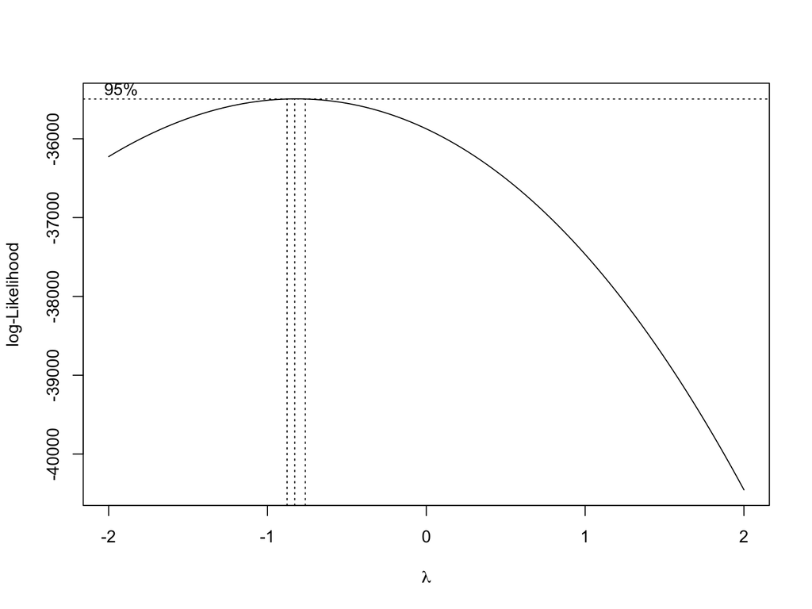

```r
MASS::boxcox(rt ~1+numerical_distance+size_rc+SpC+Subj, data=dat)
```

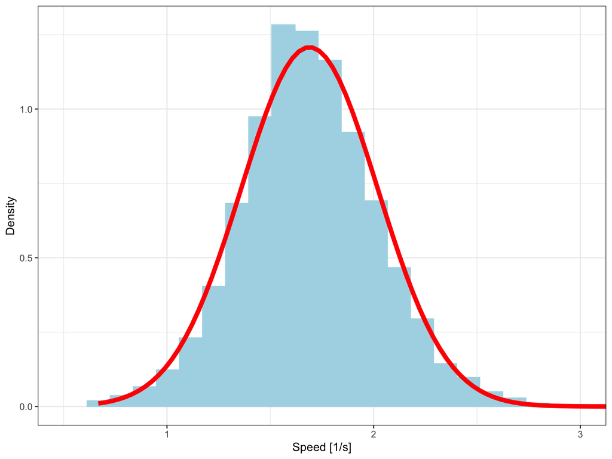

```r
dat$speed <- 1000/dat$rt

# boxcox is in favor or response speed (i.e., Hz)
ggplot(dat, aes(x=speed)) +
  geom_histogram( aes(y=..density..), colour="lightblue", fill="lightblue") +
  stat_function(fun=dnorm, color="red", size=2,
                 args=list(mean=mean(dat$speed),
                           sd=sd(dat$speed))) +
  xlab("Speed [1/s]") + ylab("Density") +
  coord_cartesian(xlim=c(0.5, 3)) +theme_bw()
```

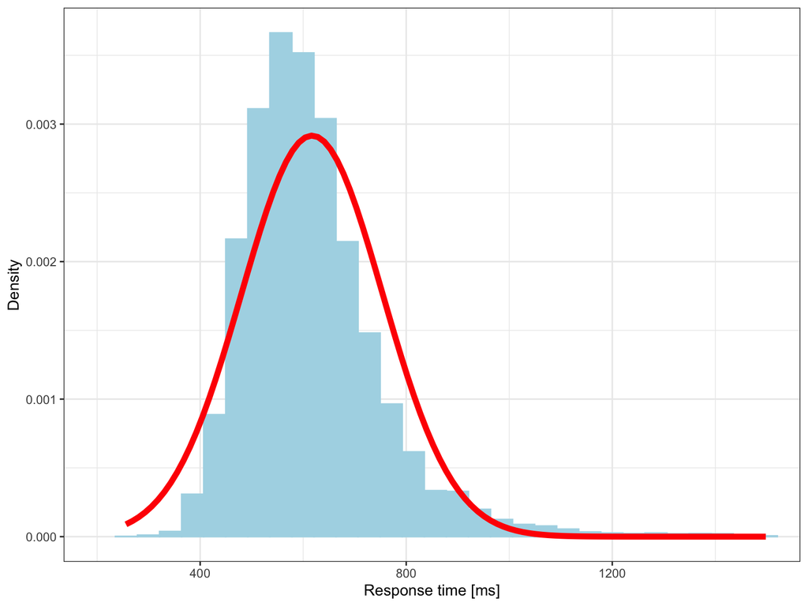

```r
# compare with response time
ggplot(dat, aes(x=rt)) +
  geom_histogram( aes(y=..density..), colour="lightblue", fill="lightblue") +
  stat_function(fun=dnorm, color="red", size=2,
                 args=list(mean=mean(dat$rt),
                           sd=sd(dat$rt))) +
  xlab("Response time [ms]") + ylab("Density") +
  coord_cartesian(xlim=c(200, 1500)) +theme_bw()
```

# 3 RK Alternative: Top-down strategy

## 3.1 Show data and save as arrow file

We use the arrow file as input for Julia.

```r
glimpse(dat)
```

```
Rows: 12,346
Columns: 13
$ Subj               <fct> S101, S101, S101, S101, S101, S101, S101, S101, S10…
$ digit              <dbl> 1, 9, 4, 2, 8, 9, 8, 3, 1, 2, 9, 3, 2, 7, 1, 2, 9, …
$ size               <dbl> 30, 42, 30, 59, 165, 30, 30, 232, 59, 165, 59, 42, …
$ pos                <dbl> 100, -300, -300, -300, 300, -200, -100, 300, 300, 2…
$ rt                 <dbl> 551, 560, 658, 598, 458, 557, 555, 518, 540, 442, 5…
$ pos_rc             <dbl> 1, -3, -3, -3, 3, -2, -1, 3, 3, 2, -2, -1, 3, 2, -1…
$ size_rc            <dbl> -3, -2, -3, -1, 2, -3, -3, 3, -1, 2, -1, -2, -1, 1,…
$ numerical_distance <dbl> 4, 4, 1, 3, 3, 4, 3, 2, 4, 3, 4, 2, 3, 2, 4, 3, 4, …
$ SiC                <dbl> 1.00000000, -0.66666667, 0.25000000, 0.25000000, 0.…
$ SpC                <dbl> -0.33333333, -1.00000000, 0.25000000, 0.75000000, 0…
$ P_SiC              <dbl> NA, 1.00000000, -0.66666667, 0.25000000, 0.25000000…
$ P_SpC              <dbl> NA, -0.33333333, -1.00000000, 0.25000000, 0.7500000…
$ speed              <dbl> 1.814882, 1.785714, 1.519757, 1.672241, 2.183406, 1…
```

```r
dat <-
  dat |>
  select(Subj, digit, size, size_rc, pos, pos_rc, numerical_distance, SiC, SpC, P_SiC, P_SpC, speed)

write_feather(dat, "./data/Lindemann_NumMeaning.arrow")
```

## 3.2 Model selection

Note the original specification included all higher-order fixed-effects interactions (`SiC*SpC*P_SiC*P_SpC`). Therefore, the five simple interactions terms were redundant. The non-redundant interactions were not significant. Therefore, we assume that only main effects and five simple interactions are intended. In balanced designs, model selection is not affected (much) by non-significant higher-order interactions.

### 3.2.1 Complex LMM

We start with complex LMM; not maximal because no interaction terms in RES

```r
m_cpx =  lmer(speed ~ 1 + numerical_distance + size_rc + pos_rc + SiC+SpC+P_SiC+P_SpC +
                          SiC:SpC + SiC:P_SiC + SiC:P_SpC + SpC:P_SiC + SpC:P_SpC +
                     (1 + numerical_distance + size_rc + pos_rc +
                          SiC + SpC + P_SiC + P_SpC | Subj),
                        REML=FALSE, control=lmerControl(calc.derivs=FALSE), data =dat)
```

```
boundary (singular) fit: see help('isSingular')
```

```r
summary(rePCA(m_cpx))  # not ok
```

```
$Subj
Importance of components:
                         [,1]    [,2]    [,3]    [,4]     [,5]      [,6]
Standard deviation     0.6905 0.08885 0.06924 0.05110 0.001572 8.899e-05
Proportion of Variance 0.9689 0.01605 0.00974 0.00531 0.000010 0.000e+00
Cumulative Proportion  0.9689 0.98495 0.99469 0.99999 1.000000 1.000e+00
                            [,7]      [,8]
Standard deviation     6.185e-05 3.368e-06
Proportion of Variance 0.000e+00 0.000e+00
Cumulative Proportion  1.000e+00 1.000e+00
```

```r
VarCorr(m_cpx)
```

```
 Groups   Name               Std.Dev.  Corr
 Subj     (Intercept)        0.1809357
          numerical_distance 0.0157225  0.048
          size_rc            0.0081782  0.770  0.256
          pos_rc             0.0050450 -0.193  0.424  0.348
          SiC                0.0150370  0.493  0.120  0.316  0.336
          SpC                0.0159457  0.548  0.100  0.936  0.518  0.213
          P_SiC              0.0095478  0.576 -0.782  0.213 -0.488  0.270
          P_SpC              0.0188600  0.126 -0.089  0.436 -0.107 -0.700
 Residual                    0.2628864







  0.187
  0.512  0.049
```

This model is overparameterized.

### 3.2.2 Very simple LMM

```r
m_voi =  lmer(speed ~ 1 + numerical_distance + size_rc + pos_rc + SiC+SpC+P_SiC+P_SpC +
                          SiC:SpC + SiC:P_SiC + SiC:P_SpC + SpC:P_SiC + SpC:P_SpC +
                     (1 | Subj),
                         REML =FALSE, control=lmerControl(calc.derivs=FALSE), data =dat)
anova(m_voi, m_cpx)
```

```
Data: dat
Models:
m_voi: speed ~ 1 + numerical_distance + size_rc + pos_rc + SiC + SpC + P_SiC + P_SpC + SiC:SpC + SiC:P_SiC + SiC:P_SpC + SpC:P_SiC + SpC:P_SpC + (1 | Subj)
m_cpx: speed ~ 1 + numerical_distance + size_rc + pos_rc + SiC + SpC + P_SiC + P_SpC + SiC:SpC + SiC:P_SiC + SiC:P_SpC + SpC:P_SiC + SpC:P_SpC + (1 + numerical_distance + size_rc + pos_rc + SiC + SpC + P_SiC + P_SpC | Subj)
      npar    AIC    BIC  logLik deviance  Chisq Df Pr(>Chisq)
m_voi   15 2459.6 2570.8 -1214.8   2429.6
m_cpx   50 2444.8 2815.7 -1172.4   2344.8 84.733 35   5.23e-06 ***
---
Signif. codes:  0 '***' 0.001 '**' 0.01 '*' 0.05 '.' 0.1 ' ' 1
```

The model probably misses some reliable individual differences.

### 3.2.3 Zero-correlation parameter LMM

We force CPs of LMM `m_cpx` to zero.

```r
m_zcp =  lmer(speed ~ 1 + numerical_distance + size_rc + pos_rc + SiC+SpC+P_SiC+P_SpC +
                          SiC:SpC + SiC:P_SiC + SiC:P_SpC + SpC:P_SiC + SpC:P_SpC +
                     (1 + numerical_distance + size_rc + pos_rc +
                          SiC + SpC + P_SiC + P_SpC || Subj),
                        REML =FALSE, control=lmerControl(calc.derivs=FALSE), data =dat)
summary(rePCA(m_zcp))  # not ok
```

```
$Subj
Importance of components:
                         [,1]    [,2]    [,3]    [,4]    [,5]    [,6]      [,7]
Standard deviation     0.6907 0.05976 0.05601 0.03204 0.02873 0.01847 0.0007308
Proportion of Variance 0.9817 0.00735 0.00645 0.00211 0.00170 0.00070 0.0000000
Cumulative Proportion  0.9817 0.98903 0.99549 0.99760 0.99930 1.00000 1.0000000
                            [,8]
Standard deviation     0.0004382
Proportion of Variance 0.0000000
Cumulative Proportion  1.0000000
```

```r
VarCorr(m_zcp)
```

```
 Groups   Name               Std.Dev.
 Subj     (Intercept)        0.18186255
 Subj.1   numerical_distance 0.01573431
 Subj.2   size_rc            0.00756409
 Subj.3   pos_rc             0.00486384
 Subj.4   SiC                0.00019243
 Subj.5   SpC                0.00843507
 Subj.6   P_SiC              0.00011538
 Subj.7   P_SpC              0.01474623
 Residual                    0.26329648
```

```r
anova(m_voi, m_zcp, m_cpx)
```

```
Data: dat
Models:
m_voi: speed ~ 1 + numerical_distance + size_rc + pos_rc + SiC + SpC + P_SiC + P_SpC + SiC:SpC + SiC:P_SiC + SiC:P_SpC + SpC:P_SiC + SpC:P_SpC + (1 | Subj)
m_zcp: speed ~ 1 + numerical_distance + size_rc + pos_rc + SiC + SpC + P_SiC + P_SpC + SiC:SpC + SiC:P_SiC + SiC:P_SpC + SpC:P_SiC + SpC:P_SpC + ((1 | Subj) + (0 + numerical_distance | Subj) + (0 + size_rc | Subj) + (0 + pos_rc | Subj) + (0 + SiC | Subj) + (0 + SpC | Subj) + (0 + P_SiC | Subj) + (0 …
m_cpx: speed ~ 1 + numerical_distance + size_rc + pos_rc + SiC + SpC + P_SiC + P_SpC + SiC:SpC + SiC:P_SiC + SiC:P_SpC + SpC:P_SiC + SpC:P_SpC + (1 + numerical_distance + size_rc + pos_rc + SiC + SpC + P_SiC + P_SpC | Subj)
      npar    AIC    BIC  logLik deviance  Chisq Df Pr(>Chisq)
m_voi   15 2459.6 2570.8 -1214.8   2429.6
m_zcp   22 2434.6 2597.8 -1195.3   2390.6 39.001  7  1.953e-06 ***
m_cpx   50 2444.8 2815.7 -1172.4   2344.8 45.731 28    0.01858 *
---
Signif. codes:  0 '***' 0.001 '**' 0.01 '*' 0.05 '.' 0.1 ' ' 1
```

We do no loose goodness of fit with LMM `m_zcp` relative to LMM `m_cpx`; both AIC and BIC increase with model complexity. However, there are reliable individual differences in some of the VCs if we go by AIC relative to LMM `m_voi`.

LMM `m_zcp` is still overparameterized.

### 3.2.4 Parsimonious LMM

```r
m_prsm =  lmer(speed ~ 1 + numerical_distance + size_rc + pos_rc + SiC+SpC+P_SiC+P_SpC +
                          SiC:SpC + SiC:P_SiC + SiC:P_SpC + SpC:P_SiC + SpC:P_SpC +
                       (1 + numerical_distance + size_rc + SpC + P_SpC || Subj),
                        REML =FALSE, control=lmerControl(calc.derivs=FALSE), data =dat)
summary(rePCA(m_prsm))  # ok
```

```
$Subj
Importance of components:
                         [,1]    [,2]    [,3]    [,4]    [,5]
Standard deviation     0.6898 0.05961 0.05521 0.03124 0.02868
Proportion of Variance 0.9827 0.00734 0.00629 0.00201 0.00170
Cumulative Proportion  0.9827 0.98999 0.99629 0.99830 1.00000
```

```r
VarCorr(m_prsm)
```

```
 Groups   Name               Std.Dev.
 Subj     (Intercept)        0.1817823
 Subj.1   numerical_distance 0.0157075
 Subj.2   size_rc            0.0075584
 Subj.3   SpC                0.0082309
 Subj.4   P_SpC              0.0145493
 Residual                    0.2635133
```

```r
anova(m_voi, m_prsm, m_zcp, m_cpx)
```

```
Data: dat
Models:
m_voi: speed ~ 1 + numerical_distance + size_rc + pos_rc + SiC + SpC + P_SiC + P_SpC + SiC:SpC + SiC:P_SiC + SiC:P_SpC + SpC:P_SiC + SpC:P_SpC + (1 | Subj)
m_prsm: speed ~ 1 + numerical_distance + size_rc + pos_rc + SiC + SpC + P_SiC + P_SpC + SiC:SpC + SiC:P_SiC + SiC:P_SpC + SpC:P_SiC + SpC:P_SpC + ((1 | Subj) + (0 + numerical_distance | Subj) + (0 + size_rc | Subj) + (0 + SpC | Subj) + (0 + P_SpC | Subj))
m_zcp: speed ~ 1 + numerical_distance + size_rc + pos_rc + SiC + SpC + P_SiC + P_SpC + SiC:SpC + SiC:P_SiC + SiC:P_SpC + SpC:P_SiC + SpC:P_SpC + ((1 | Subj) + (0 + numerical_distance | Subj) + (0 + size_rc | Subj) + (0 + pos_rc | Subj) + (0 + SiC | Subj) + (0 + SpC | Subj) + (0 + P_SiC | Subj) + (0 …
m_cpx: speed ~ 1 + numerical_distance + size_rc + pos_rc + SiC + SpC + P_SiC + P_SpC + SiC:SpC + SiC:P_SiC + SiC:P_SpC + SpC:P_SiC + SpC:P_SpC + (1 + numerical_distance + size_rc + pos_rc + SiC + SpC + P_SiC + P_SpC | Subj)
       npar    AIC    BIC  logLik deviance  Chisq Df Pr(>Chisq)
m_voi    15 2459.6 2570.8 -1214.8   2429.6
m_prsm   19 2432.0 2572.9 -1197.0   2394.0 35.609  4  3.482e-07 ***
m_zcp    22 2434.6 2597.8 -1195.3   2390.6  3.392  3    0.33504
m_cpx    50 2444.8 2815.7 -1172.4   2344.8 45.731 28    0.01858 *
---
Signif. codes:  0 '***' 0.001 '**' 0.01 '*' 0.05 '.' 0.1 ' ' 1
```

```r
anova(m_voi, m_prsm, m_cpx)
```

```
Data: dat
Models:
m_voi: speed ~ 1 + numerical_distance + size_rc + pos_rc + SiC + SpC + P_SiC + P_SpC + SiC:SpC + SiC:P_SiC + SiC:P_SpC + SpC:P_SiC + SpC:P_SpC + (1 | Subj)
m_prsm: speed ~ 1 + numerical_distance + size_rc + pos_rc + SiC + SpC + P_SiC + P_SpC + SiC:SpC + SiC:P_SiC + SiC:P_SpC + SpC:P_SiC + SpC:P_SpC + ((1 | Subj) + (0 + numerical_distance | Subj) + (0 + size_rc | Subj) + (0 + SpC | Subj) + (0 + P_SpC | Subj))
m_cpx: speed ~ 1 + numerical_distance + size_rc + pos_rc + SiC + SpC + P_SiC + P_SpC + SiC:SpC + SiC:P_SiC + SiC:P_SpC + SpC:P_SiC + SpC:P_SpC + (1 + numerical_distance + size_rc + pos_rc + SiC + SpC + P_SiC + P_SpC | Subj)
       npar    AIC    BIC  logLik deviance  Chisq Df Pr(>Chisq)
m_voi    15 2459.6 2570.8 -1214.8   2429.6
m_prsm   19 2432.0 2572.9 -1197.0   2394.0 35.609  4  3.482e-07 ***
m_cpx    50 2444.8 2815.7 -1172.4   2344.8 49.123 31    0.02047 *
---
Signif. codes:  0 '***' 0.001 '**' 0.01 '*' 0.05 '.' 0.1 ' ' 1
```

LMM `m_prsm` does fit better than LMM `m_voi` and does not fit worse than LMM `m_cpx`.

# 4 Figures

## 4.1 Conditional means

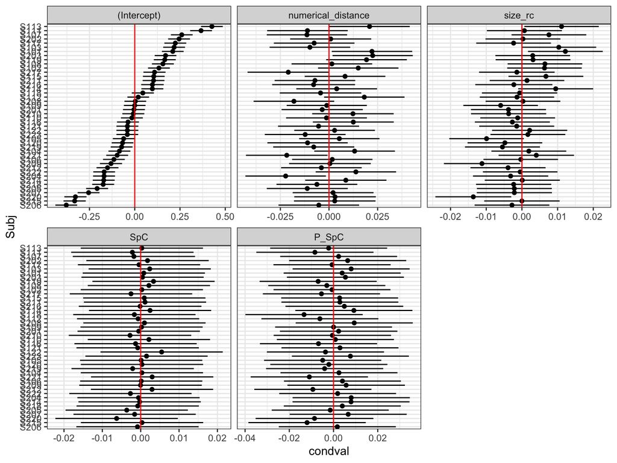

```r
cond_means <-
  as_tibble(ranef(m_prsm, condVar=TRUE)) |>
  rename(Term=term, Subj=grp)

cond_means |>
   ggplot(aes(y=Subj, x=condval)) +
   geom_point() + facet_wrap(~Term, scales="free_x") +
   geom_errorbarh(aes(xmin=condval -2*condsd,
                      xmax=condval +2*condsd), height=0) +
   geom_vline(xintercept=0, color="red") + theme_bw()
```

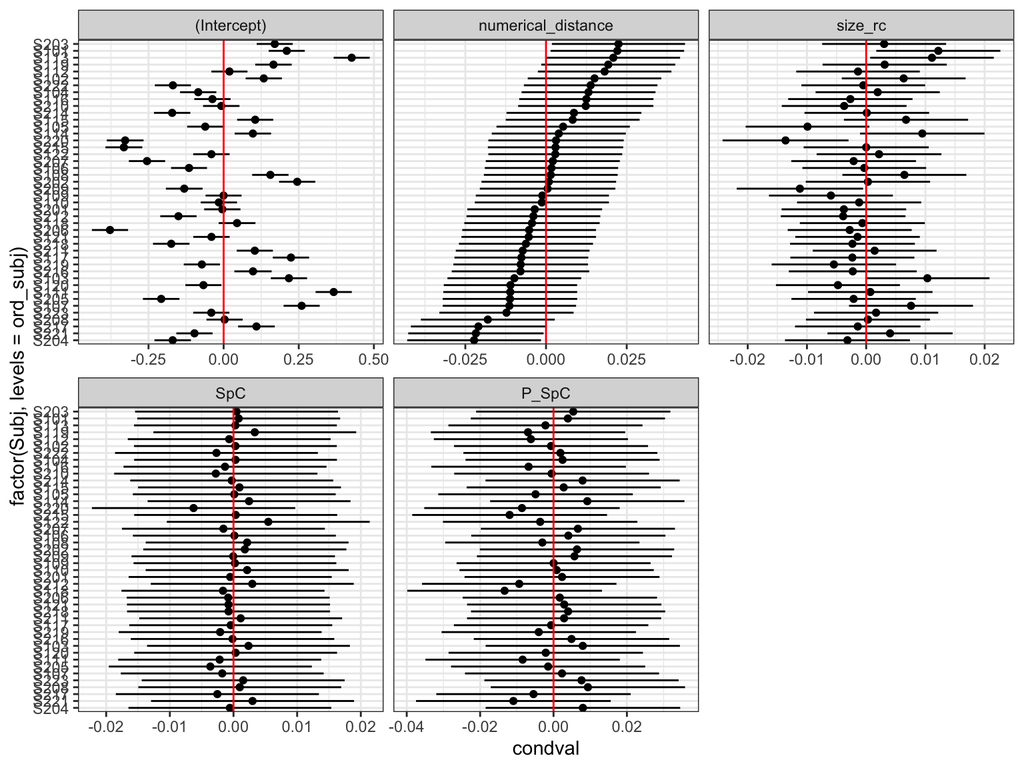

```r
# Subjects ordered by numerical_distance effect
ord_subj <- cond_means |> filter(Term=="numerical_distance") |> arrange(condval) |> pull(Subj)

cond_means |>
   ggplot(aes(y=factor(Subj, levels=ord_subj), x=condval)) +
   geom_point() + facet_wrap(~Term, scales="free_x") +
   geom_errorbarh(aes(xmin=condval -2*condsd,
                      xmax=condval +2*condsd), height=0) +
   geom_vline(xintercept=0, color="red") + theme_bw()
```

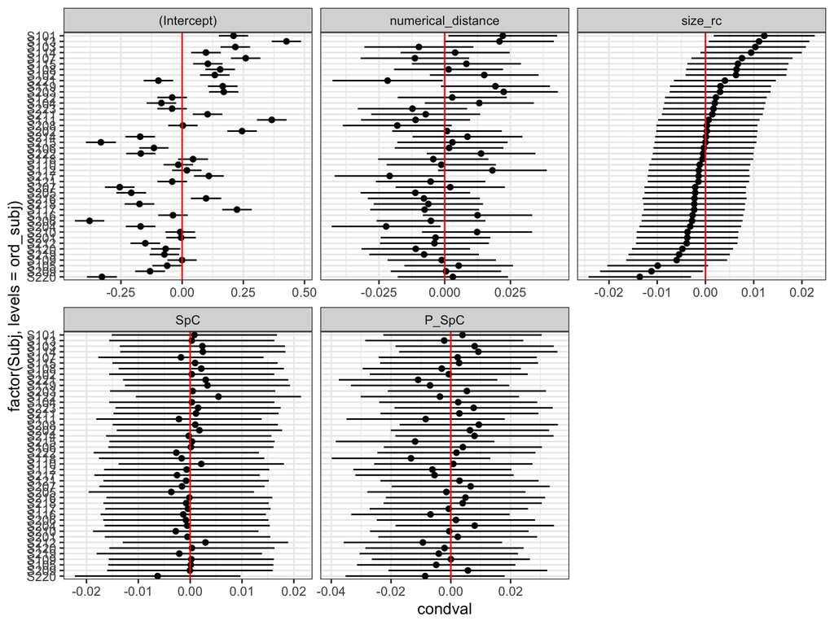

```r
# Subjects ordered by size_rc effect
ord_subj <- cond_means |> filter(Term=="size_rc") |> arrange(condval) |> pull(Subj)

cond_means |>
   ggplot(aes(y=factor(Subj, levels=ord_subj), x=condval)) +
   geom_point() + facet_wrap(~Term, scales="free_x") +
   geom_errorbarh(aes(xmin=condval -2*condsd,
                      xmax=condval +2*condsd), height=0) +
   geom_vline(xintercept=0, color="red") + theme_bw()
```

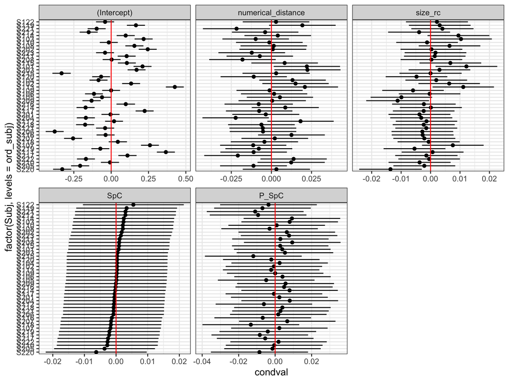

```r
# Subjects ordered by SpC effect
ord_subj <- cond_means |> filter(Term=="SpC") |> arrange(condval) |> pull(Subj)

cond_means |>
   ggplot(aes(y=factor(Subj, levels=ord_subj), x=condval)) +
   geom_point() + facet_wrap(~Term, scales="free_x") +
   geom_errorbarh(aes(xmin=condval -2*condsd,
                      xmax=condval +2*condsd), height=0) +
   geom_vline(xintercept=0, color="red") + theme_bw()
```

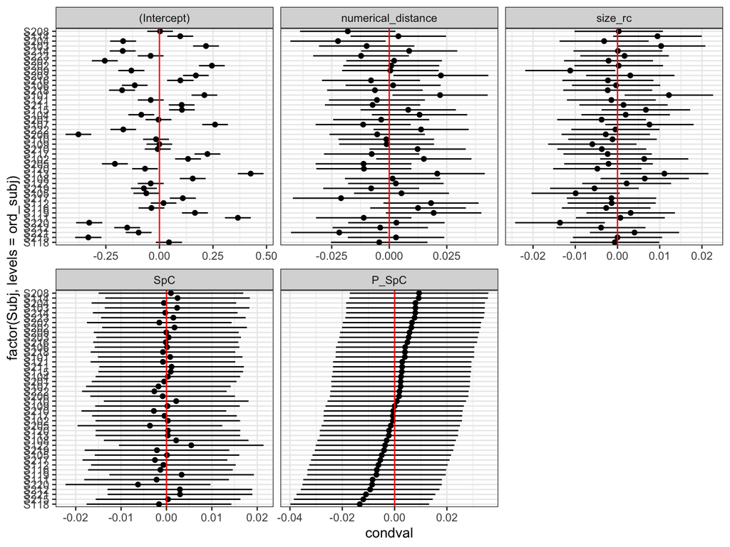

```r
# Subjects ordered by P_SpC effect
ord_subj <- cond_means |> filter(Term=="P_SpC") |> arrange(condval) |> pull(Subj)

cond_means |>
   ggplot(aes(y=factor(Subj, levels=ord_subj), x=condval)) +
   geom_point() + facet_wrap(~Term, scales="free_x") +
   geom_errorbarh(aes(xmin=condval -2*condsd,
                      xmax=condval +2*condsd), height=0) +
   geom_vline(xintercept=0, color="red") + theme_bw()
```

**Evaluation of credibility intervals**

- `numerical_distance` effect: Credibility intervals of most subjects cross the zero line; a few are on either side.
- `size_rc` effect: dito
- `SpC` and `P_SpC` effects: no evidence for individual differences in the conditional modes; all of credibility intervals cross the zero line.

Could we get rid of the corresponding VCs?

```r
m_prsm2 =  lmer(speed ~ 1 + numerical_distance + size_rc + pos_rc + SiC+SpC+P_SiC+P_SpC +
                          SiC:SpC + SiC:P_SiC + SiC:P_SpC + SpC:P_SiC + SpC:P_SpC +
                       (1 + numerical_distance + size_rc  || Subj),
                        REML =FALSE, control=lmerControl(calc.derivs=FALSE), data =dat)
summary(rePCA(m_prsm2))  # ok
```

```
$Subj
Importance of components:
                         [,1]    [,2]    [,3]
Standard deviation     0.6896 0.05944 0.02870
Proportion of Variance 0.9909 0.00736 0.00172
Cumulative Proportion  0.9909 0.99828 1.00000
```

```r
VarCorr(m_prsm2)
```

```
 Groups   Name               Std.Dev.
 Subj     (Intercept)        0.1818073
 Subj.1   numerical_distance 0.0156717
 Subj.2   size_rc            0.0075664
 Residual                    0.2636435
```

```r
anova(m_voi, m_prsm2, m_prsm)
```

```
Data: dat
Models:
m_voi: speed ~ 1 + numerical_distance + size_rc + pos_rc + SiC + SpC + P_SiC + P_SpC + SiC:SpC + SiC:P_SiC + SiC:P_SpC + SpC:P_SiC + SpC:P_SpC + (1 | Subj)
m_prsm2: speed ~ 1 + numerical_distance + size_rc + pos_rc + SiC + SpC + P_SiC + P_SpC + SiC:SpC + SiC:P_SiC + SiC:P_SpC + SpC:P_SiC + SpC:P_SpC + ((1 | Subj) + (0 + numerical_distance | Subj) + (0 + size_rc | Subj))
m_prsm: speed ~ 1 + numerical_distance + size_rc + pos_rc + SiC + SpC + P_SiC + P_SpC + SiC:SpC + SiC:P_SiC + SiC:P_SpC + SpC:P_SiC + SpC:P_SpC + ((1 | Subj) + (0 + numerical_distance | Subj) + (0 + size_rc | Subj) + (0 + SpC | Subj) + (0 + P_SpC | Subj))
        npar    AIC    BIC  logLik deviance   Chisq Df Pr(>Chisq)
m_voi     15 2459.6 2570.8 -1214.8   2429.6
m_prsm2   17 2428.9 2555.0 -1197.4   2394.9 34.7131  2  2.898e-08 ***
m_prsm    19 2432.0 2572.9 -1197.0   2394.0  0.8962  2     0.6388
---
Signif. codes:  0 '***' 0.001 '**' 0.01 '*' 0.05 '.' 0.1 ' ' 1
```

Yes, we could.

## 4.2 Plot of higher-order interaction

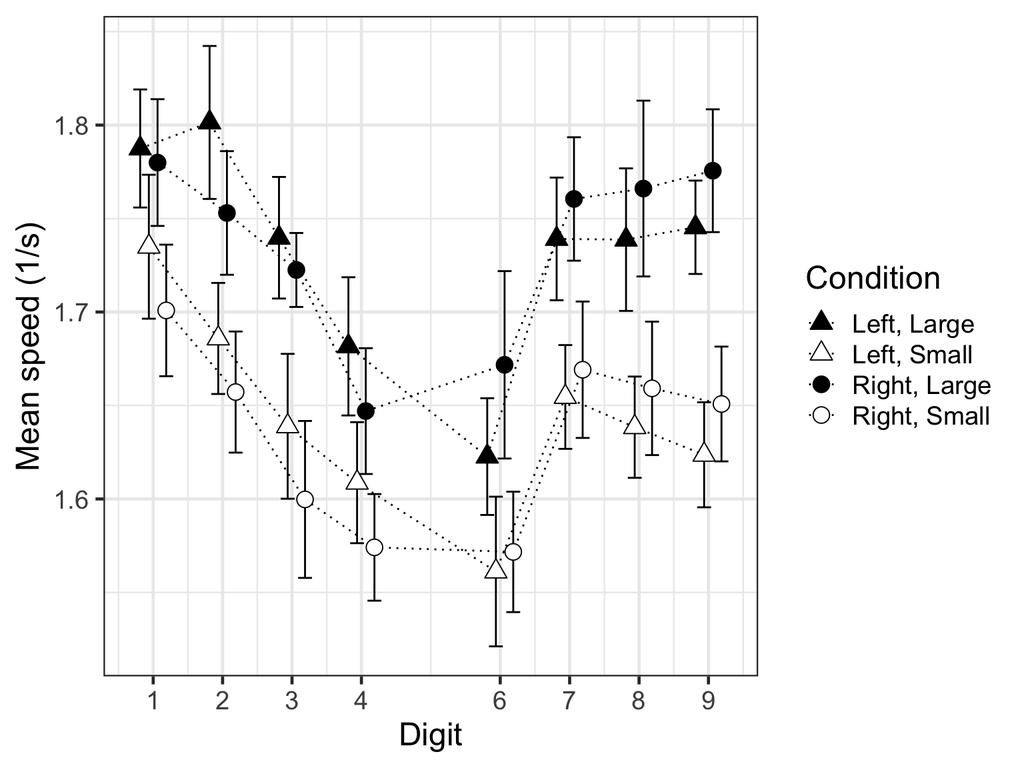

# 5 Appendix